# Sistemas y Señales Biomédicos

Ingeniería Biomédica

Ph.D. Pablo Eduardo Caicedo Rodríguez

2026-09-27

# Sistemas y Señales Biomedicos - SYSB

## Digital Filter – Introduction

- It is a mathematical algorithm or system that processes digital signals.
- They enhance, suppress, or modify specific frequency components.
- These filters are essential for removing noise, extracting relevant information, and improving signal quality.

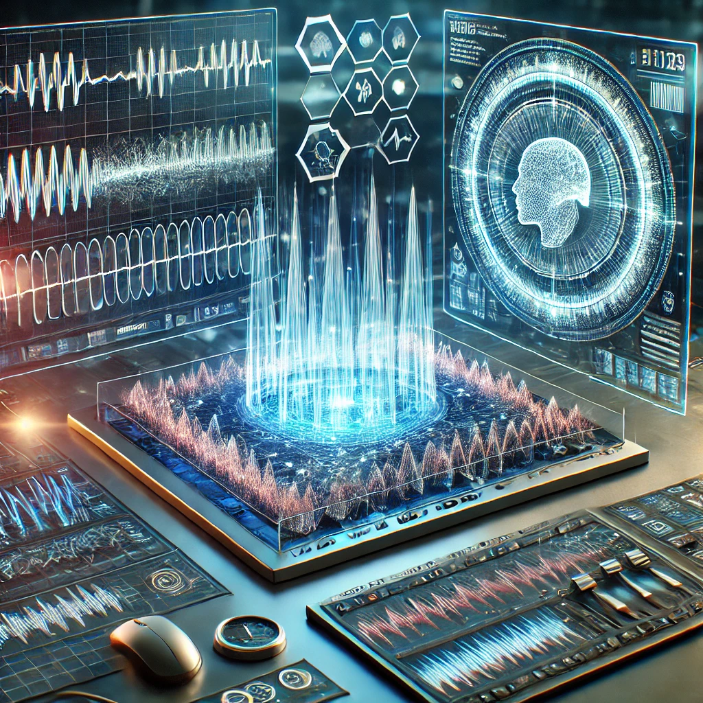

## What is a *system*?

A **system** is a rule that maps an input signal to an output signal. In continuous time and discrete time we depict and denote:
$$x(t)\ \longrightarrow\ y(t),\qquad x[n]\ \longrightarrow\ y[n].$$
These are the standard input–output representations used throughout the text.

## Input–output operator notation

We often write the system as an operator ( {} ):
$$y(t)=\mathcal{T}\{x(t)\},\qquad y[n]=\mathcal{T}\{x[n]\}.$$
Block diagrams are used to represent systems and **interconnections** (series/cascade and parallel).

## Overview: what is an input–output relation?

A **system** specifies how an input signal produces an output signal:
$$x(t)\ \longrightarrow\ y(t),\qquad x[n]\ \longrightarrow\ y[n].$$
We study **types of relations** used in analysis and design: - Memoryless (static) mappings - Differential/difference-equation descriptions - Convolution (LTI) - Transform-domain forms (frequency, Laplace, (z)) - State–space (first-order vector form) - Time-varying vs time-invariant, linear vs nonlinear

## Memoryless (static) relations

A **memoryless** or **static** system relates input and output at the same instant:
$$y(t)=F\!\big(x(t)\big),\qquad y[n]=F\!\big(x[n]\big).$$
Examples: (y=|x|), (y=x^2), saturation and clipping nonlinearities. These are common as pointwise nonlinear stages preceding or following LTI blocks.

## Linear constant-coefficient differential equations (CT)

Many continuous-time LTI systems are described by an LCCDE:
$$\sum_{k=0}^{N} a_k\,\frac{d^{\,k} y(t)}{dt^{\,k}}
\;=\;
\sum_{m=0}^{M} b_m\,\frac{d^{\,m} x(t)}{dt^{\,m}},
\qquad a_0\neq 0.$$
Coefficients (a_k,b_m) are constants for **time invariance**. This form covers standard electrical/mechanical systems and filters.

## Linear constant-coefficient difference equations (DT)

Discrete-time LTI systems admit an LCCD equation:
$$\sum_{k=0}^{N} a_k\,y[n-k]\;=\;\sum_{m=0}^{M} b_m\,x[n-m],\qquad a_0\neq 0.$$
This representation includes IIR/FIR digital filters and many algorithmic recursions.

## Convolution relations (LTI)

For **LTI** systems the input–output relation is convolution with the impulse response:
$$y(t)=\int_{-\infty}^{\infty} h(\tau)\,x(t-\tau)\,d\tau,\qquad
y[n]=\sum_{k=-\infty}^{\infty} h[k]\;x[n-k].$$
Here (h(t)) or (h[n]) is the output to a unit impulse. Causality for LTI corresponds to (h(t)=0) for (t<0) (or (h[n]=0) for (n<0)).

## Frequency-domain input–output (Fourier)

When Fourier transforms exist, convolution becomes multiplication:
$$Y(\omega)=H(\omega)\,X(\omega),\qquad
Y\!\big(e^{j\omega}\big)=H\!\big(e^{j\omega}\big)\,X\!\big(e^{j\omega}\big).$$
(H) is the **frequency response** (CTFT/DTFT). Magnitude (|H|) scales, phase (H) shifts/warps timing.

## Laplace and (z)-transform forms

With Laplace and (z)-transforms (for appropriate regions of convergence):
$$Y(s)=H(s)\,X(s),\qquad Y(z)=H(z)\,X(z),$$
and for LCCDE/LCCD systems
$$H(s)=\frac{b_0+b_1 s+\cdots+b_M s^M}{a_0+a_1 s+\cdots+a_N s^N},\qquad
H(z)=\frac{b_0+b_1 z^{-1}+\cdots+b_M z^{-M}}{a_0+a_1 z^{-1}+\cdots+a_N z^{-N}}.$$
These rational forms support pole–zero analysis and stability checks.

## State–space (first-order vector) description

An equivalent input–output formulation uses **state variables**:
$$\dot{\mathbf{s}}(t)=\mathbf{A}\,\mathbf{s}(t)+\mathbf{b}\,x(t),\qquad
y(t)=\mathbf{c}^\top\mathbf{s}(t)+d\,x(t).$$
Discrete time:
$$\mathbf{s}[n+1]=\mathbf{A}\,\mathbf{s}[n]+\mathbf{b}\,x[n],\qquad
y[n]=\mathbf{c}^\top\mathbf{s}[n]+d\,x[n].$$
This first-order form is algebraically equivalent to LCCDE/LCCD for LTI systems.

## Time-varying vs time-invariant relations

- **Time-invariant (TI)**: coefficients and operators do not change with time/index; shifts commute with the system.
- **Time-varying (TV)**: coefficients depend on (t) or (n):
  $$\sum_{k=0}^{N} a_k(t)\,\frac{d^{\,k} y(t)}{dt^{\,k}}
  =\sum_{m=0}^{M} b_m(t)\,\frac{d^{\,m} x(t)}{dt^{\,m}}.$$
  TV models arise in modulated systems and adaptive filtering.

## Linear vs nonlinear relations

- **Linear**: superposition holds — additivity and homogeneity.
- **Nonlinear**: violates superposition; examples include squares, rectifiers, saturators, quantizers. Nonlinear stages are often analyzed locally or via small-signal linearization around an operating point.

## Stochastic input–output (LTI summary)

For wide-sense stationary (WSS) inputs to an LTI system:
$$\mu_y=\mu_x\,H(0)\ \text{(when defined)},\qquad
S_{yy}(\omega)=\big|H(\omega)\big|^2\,S_{xx}(\omega).$$
This links input and output statistics through (H), supporting noise and SNR analysis.

## Interconnections (examples)

- **Series (cascade):** output of System 1 feeds System 2.
- **Parallel:** both systems process the same input; outputs are summed. These patterns are foundational for building complex systems from simpler ones.

## Property: Memoryless vs. with memory

- **Memoryless:** the output at an instant depends only on the input at that same instant.
- **With memory:** the output depends on past/future values (e.g., accumulators, averagers). Example: the **summer/accumulator** (running sum) and its inverse (first difference) illustrate systems with memory:
  $$y[n]=\sum_{k=-\infty}^{n} x[k],\qquad \text{inverse: } y[n]=x[n]-x[n-1].$$
  Both are causal (see next slide)

## Property: Causality (general and LTI)

**Causal:** output depends only on present/past input values. For **LTI** systems, causality is characterized by the impulse response:
$$\text{Discrete time: } h[n]=0\ \text{for } n<0;\qquad
\text{Continuous time: } h(t)=0\ \text{for } t<0.$$
Under these conditions, the convolution reduces to depend only on past/present input.

## Property: Stability (BIBO)

**Bounded-Input Bounded-Output (BIBO) stability:** bounded input implies bounded output. For **LTI** systems:
$$\sum_{k=-\infty}^{\infty} |h[k]| < \infty \quad \Longleftrightarrow \quad \text{discrete-time LTI is stable},$$
$$\int_{-\infty}^{\infty} |h(t)|\,dt < \infty \quad \Longleftrightarrow \quad \text{continuous-time LTI is stable}.$$
These are necessary and sufficient conditions.

## Property: Linearity (superposition)

A system is **linear** if it satisfies **additivity** and **homogeneity**: for any signals (x_1,x_2) and scalar (c),
$$\mathcal{T}\{x_1+x_2\}=\mathcal{T}\{x_1\}+\mathcal{T}\{x_2\},\qquad \mathcal{T}\{c\,x\}=c\,\mathcal{T}\{x\}.$$
(These two conditions together are equivalent to linearity.)

## Property: Time invariance (definition)

A system is **time-invariant** if a shift in the input produces an identical shift in the output:
$$\mathcal{T}\{x(t-t_0)\}=y(t-t_0),\ \text{whenever}\ y(t)=\mathcal{T}\{x(t)\}.$$
Analogously in discrete time with shifts by integer indices. (Definition used throughout the text in system properties and LTI analysis.)

## Property: Invertibility

A system is **invertible** if distinct inputs produce distinct outputs; equivalently, there exists an **inverse system** that recovers the input from the output. Example pair (discrete time): the accumulator and the first-difference operator are inverses:
$$y[n]=\sum_{k=-\infty}^{n} x[k] \quad \Longleftrightarrow \quad x[n]=y[n]-y[n-1].$$

## Additional note: Interconnections and LTI analysis

For LTI systems, interconnections admit simple algebraic descriptions via transforms: e.g., in the Laplace domain, series and parallel lead to product and sum of system functions, respectively:
$$H_{\text{series}}(s)=H_1(s)H_2(s),\qquad H_{\text{parallel}}(s)=H_1(s)+H_2(s).$$

## Digital Filter – Introduction

**Importante**

The digital filter separates the noise and the information of a discrete signal.

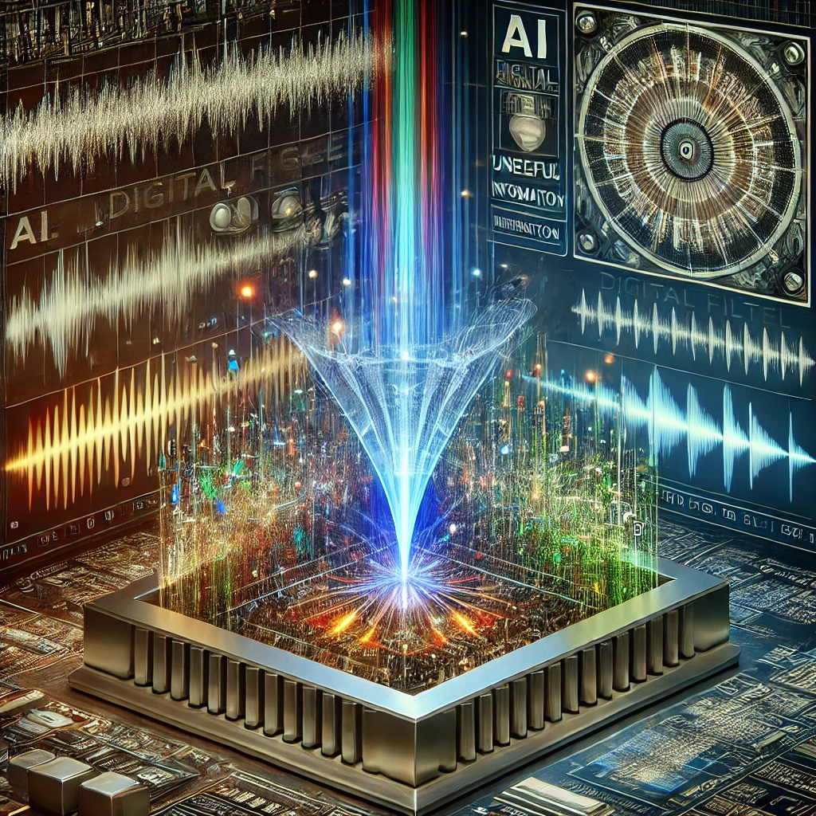

## Digital Filter – Introduction

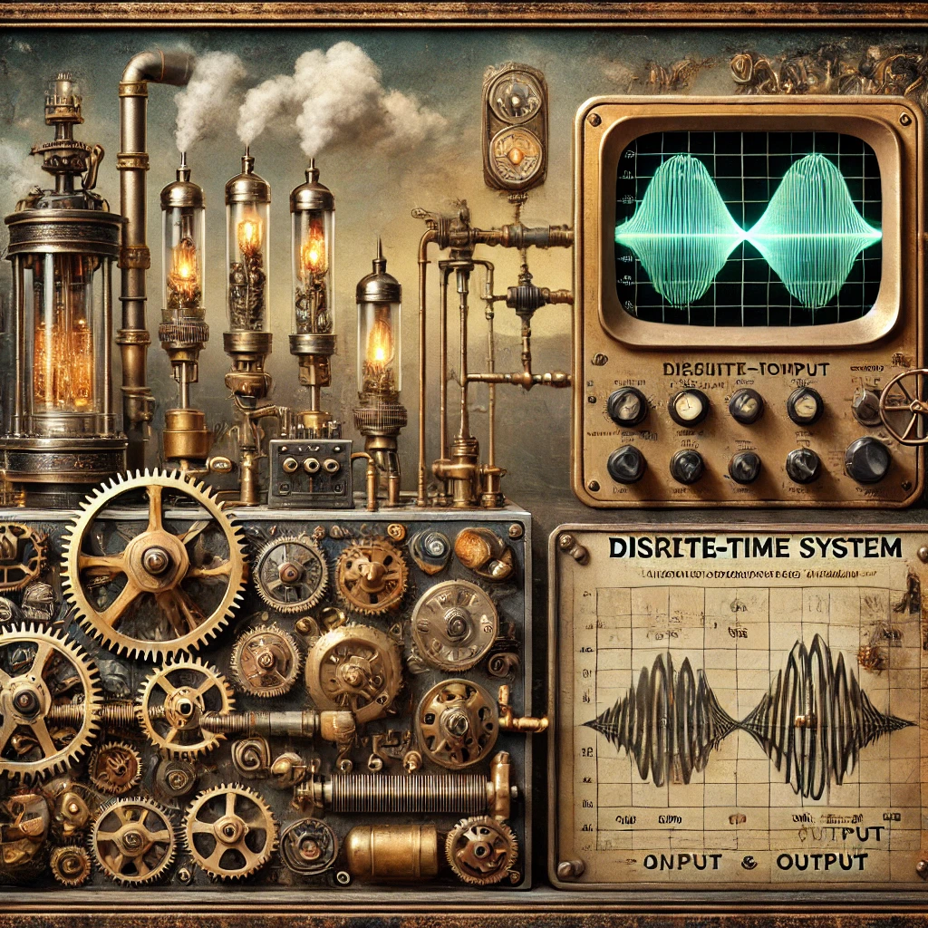

## Digital Filter – Introduction

Suppose a **discrete** time system
$$y[n] = \sum_{k=1}^{K} a_k y[n - k] + \sum_{m=0}^{M} b_m x[n - m]$$

- K y M are the order of the filter.
- We must know the initial condition.

## Examples of digital filters

**Gain**

$$y[n] = G x[n]$$

**Delay of $n_0$ samples**

$$y[n] = x[n - n_0]$$

**Two points moving average**

$$y[n] = \frac{1}{2} (x[n] + x[n - 1])$$

**Euler approximation of the derivative**

$$y[n] = \frac{x[n] - x[n - 1]}{T_s}$$

**Averaging over N consecutive epochs of duration L**

$$y[n] = \frac{1}{N} \sum_{k=0}^{N-1} x[n - kL]$$

**Trapezoidal integration formula**

$$y[n] = y[n - 1] + \frac{T_s}{2} (x[n] + x[n - 1])$$

**Digital “leaky integrator” (First-order lowpass filter)**

$$y[n] = a y[n - 1] + x[n], \quad 0 < a < 1$$

**Digital resonator (Second-order system)**

$$y[n] = a_1 y[n - 1] + a_2 y[n - 2] + b x[n], \quad a_1^2 + 4a_2 < 0$$

## The impulse response

- The impulse response, denoted as $ℎ[n]$, is the output of a digital filter when the input is a unit impulse function $\delta[n]$
- The impulse response fully describes the system. Given $h[n]$, we can determine the output for any input using convolution.
- Different types of filters (low-pass, high-pass, band-pass, etc.) have characteristic impulse responses.

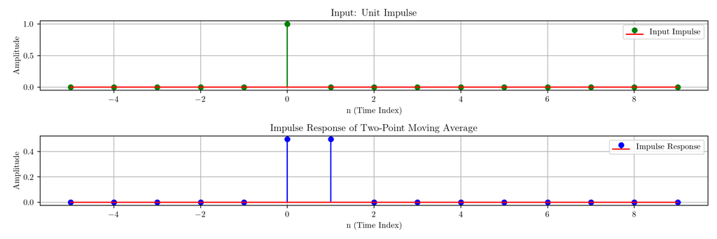

## Conditions

For a system’s response to be **fully described by its impulse response**, the system must satisfy the following key conditions.

**Linearity**

If the system responds to $x_1[n]$ with $y_1[n]$ and to $x_2[n]$ with $y_2[n]$, then:

$$y[n] = y_1[n] + y_2[n]$$

**Homogeneity**

If the input is scaled by a constant $c$, the output is also scaled:

$$\text{If } x[n] \rightarrow y[n], \text{ then } cx[n] \rightarrow cy[n]$$

**Time Invariance**

A system must be **time-invariant**, meaning a time shift in the input causes the same shift in the output:

$$\text{If } x[n] \rightarrow y[n], \text{ then } x[n - n_0] \rightarrow y[n - n_0]$$

**Causality**

A **causal system** is one where the output at time $n$ depends only on present and past inputs:

$$h[n] = 0 \quad \forall n < 0$$

**Stability**

If the impulse response does not satisfy this condition, the system may produce unbounded outputs.

$$\sum_{n=-\infty}^{\infty} |h[n]| < \infty$$

**Convolution Representation**

If all condition met then
$$y[n] = x[n] * h[n] = \sum_{m=-\infty}^{\infty} x[m] h[n - m]$$

## Convolution

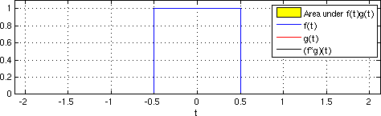

## Continuous example: the original signals

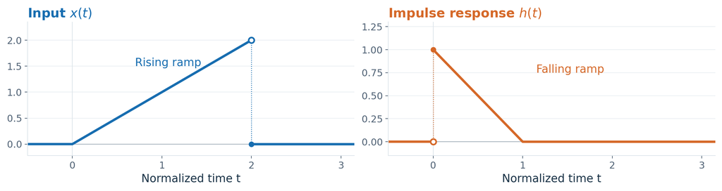

$$x(t)=\begin{cases}t,&0\leq t<2,\\0,&\text{otherwise.}\end{cases}$$

$$h(t)=\begin{cases}1-t,&0\leq t<1,\\0,&\text{otherwise.}\end{cases}$$

Both ramps have an asymmetric shape within their nonzero interval.

## Time reversal and amplitude inversion

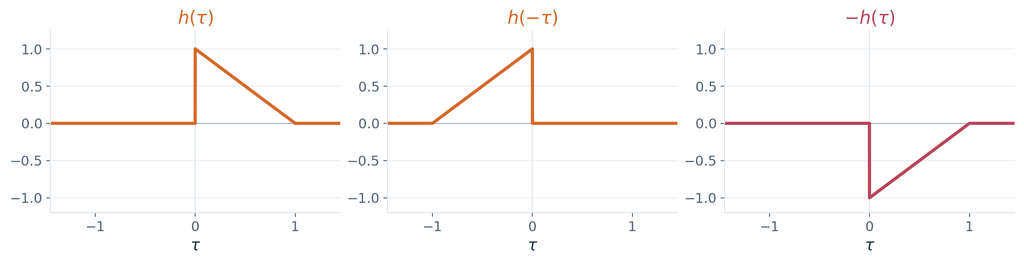

| Operation | Expression | Geometric effect |
| --- | --- | --- |
| Time reversal | $h(-\tau)$ | Reflection across the **vertical** axis |
| Amplitude inversion | $-h(\tau)$ | Reflection across the **horizontal** axis |

## Convolution for an LTI system

For a **linear, time-invariant system at initial rest**, the impulse response determines the output.

**Continuous time**

$$y(t)=\int_{-\infty}^{\infty}x(\tau)h(t-\tau)\,d\tau$$

Fix $t$, then integrate over $\tau$.

**Discrete time**

$$y[n]=\sum_{k=-\infty}^{\infty}x[k]h[n-k]$$

Fix $n$, then sum over $k$.

**The same graphical procedure**

Reverse $h$, shift it to the output time, multiply aligned amplitudes, then integrate or sum the products.

## Continuous example: reversal and shift

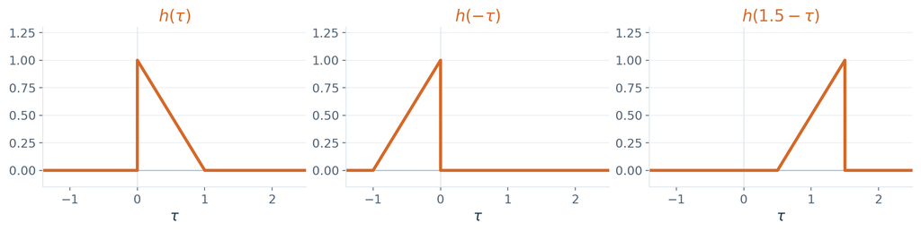

$$h(t-\tau)=1-t+\tau\qquad\text{where }0\leq t-\tau<1.$$

Thus the reversed response occupies the interval between $t-1$ and $t$.

At $t=1.5$, its ramp runs from $\tau=0.5$ to $\tau=1.5$.

## Continuous example: overlap limits

The product can contribute only where **both** signals are nonzero:

$$a(t)=\max(0,t-1),\qquad b(t)=\min(2,t).$$

$$y(t)=\int_{a(t)}^{b(t)}\tau(1-t+\tau)\,d\tau,
\qquad a(t)<b(t).$$

| Output time | Integration interval | Overlap |
| --- | --- | --- |
| $t\leq0$ | None | Before contact |
| $0<t\leq1$ | $0$ to $t$ | Entering |
| $1<t\leq2$ | $t-1$ to $t$ | Entire response overlaps |
| $2<t<3$ | $t-1$ to $2$ | Leaving |
| $t\geq3$ | None | After contact |

## Continuous example: entering overlap

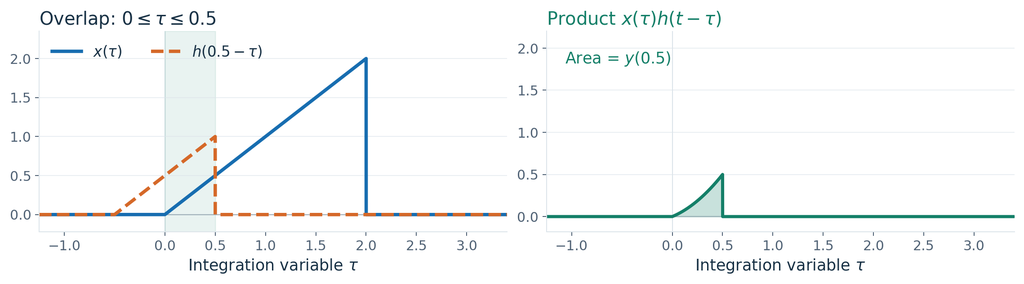

For $0<t\leq1$:
$$y(t)=\int_0^t\tau(1-t+\tau)\,d\tau
=\left[\frac{(1-t)\tau^2}{2}+\frac{\tau^3}{3}\right]_0^t
=\frac{t^2}{2}-\frac{t^3}{6}.$$

At $t=0.5$: **$y(0.5)=5/48\approx0.10417$.**

## Continuous example: full response overlap

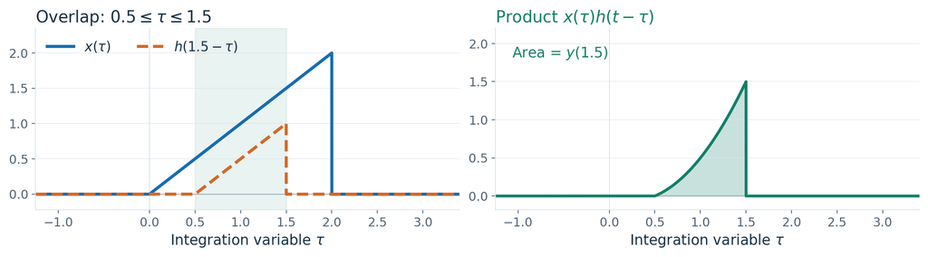

For $1<t\leq2$:
$$y(t)=\int_{t-1}^{t}\tau(1-t+\tau)\,d\tau
=\left[\frac{(1-t)\tau^2}{2}+\frac{\tau^3}{3}\right]_{t-1}^{t}
=\frac{t}{2}-\frac16.$$

At $t=1.5$: **$y(1.5)=7/12\approx0.58333$.**

## Continuous example: leaving overlap

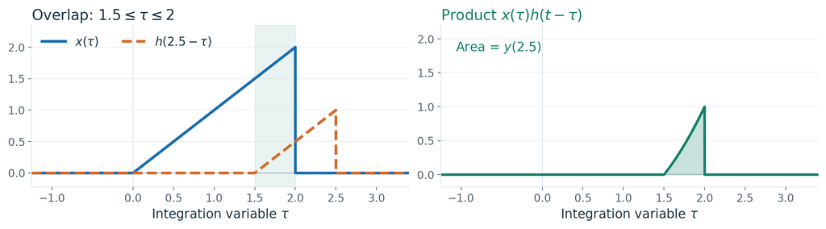

For $2<t<3$:
$$y(t)=\int_{t-1}^{2}\tau(1-t+\tau)\,d\tau
=\left[\frac{(1-t)\tau^2}{2}+\frac{\tau^3}{3}\right]_{t-1}^{2}
=\frac{(3-t)^2(t+3)}6.$$

At $t=2.5$: **$y(2.5)=11/48\approx0.22917$.**

## Continuous example: the complete output

$$y(t)=\begin{cases}
0,&t\leq0,\\
\dfrac{t^2}{2}-\dfrac{t^3}{6},&0<t\leq1,\\
\dfrac{t}{2}-\dfrac16,&1<t\leq2,\\
\dfrac{(3-t)^2(t+3)}6,&2<t<3,\\
0,&t\geq3.
\end{cases}$$

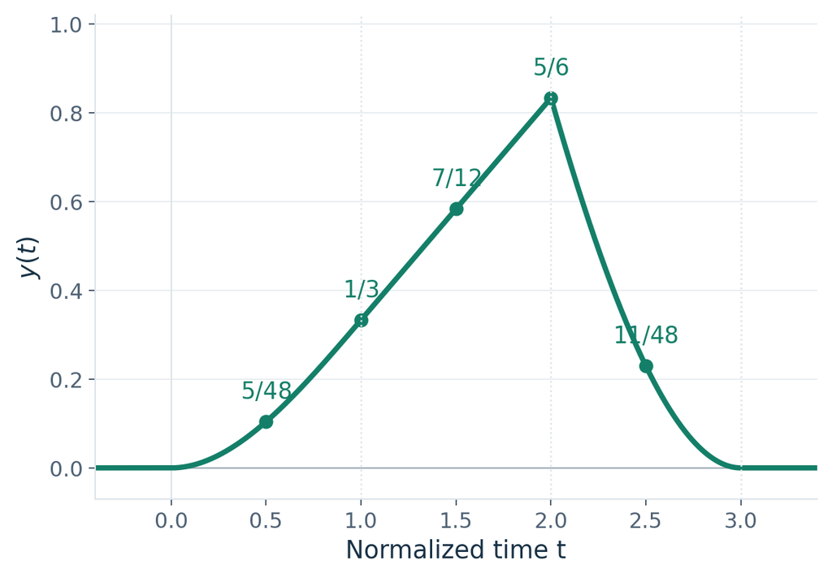

The three branches meet continuously at $t=1$ and $t=2$.

## Continuous example: sensor interpretation

The synthetic model illustrates how a **sensor with memory** combines recent input values.

- The input lasts 2 time units. The response lasts 1 time unit.
- The output continues until $t=3$, after the input has ended.
- Since $x(t)\geq0$ and $h(t)\geq0$, the output stays nonnegative.

$$\int x(t)\,dt=2,\qquad\int h(t)\,dt=\frac12,
\qquad\int y(t)\,dt=2\left(\frac12\right)=1.$$

**Gain and duration are different properties**

The impulse response has area $1/2$. This filter does not preserve the area of the input.

## Continuous example: Python calculation

```python
from scipy.integrate import quad

def y_continuous(t):
    a = max(0.0, t - 1.0)
    b = min(2.0, t)
    if a >= b:
        return 0.0
    return quad(lambda tau: tau * (1 - t + tau), a, b)[0]

for t in (0.5, 1.5, 2.5):
    print(f"y({t}) = {y_continuous(t):.5f}")
```

```
y(0.5) = 0.10417
y(1.5) = 0.58333
y(2.5) = 0.22917
```

## Discrete example: the original sequences

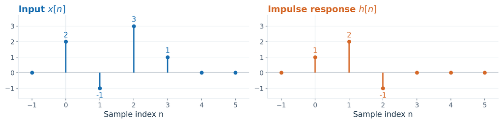

| Sample index $n$ | $0$ | $1$ | $2$ | $3$ |
| --- | --- | --- | --- | --- |
| Input $x[n]$ | $2$ | $-1$ | $3$ | $1$ |
| Impulse response $h[n]$ | $1$ | $2$ | $-1$ | $0$ |

Both sequences are zero elsewhere and asymmetric in time.

## Discrete example: reversal and shift

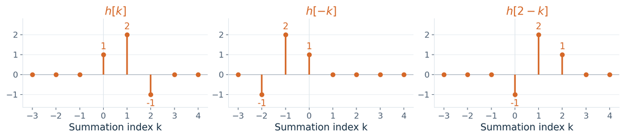

| Original sample | After reversal | After a shift by $n$ |
| --- | --- | --- |
| $h[0]=1$ | At $k=0$ | At $k=n$ |
| $h[1]=2$ | At $k=-1$ | At $k=n-1$ |
| $h[2]=-1$ | At $k=-2$ | At $k=n-2$ |

The overlap is $\max(0,n-2)\leq k\leq\min(3,n)$, for integer $k$.

## Discrete example: the first two output samples

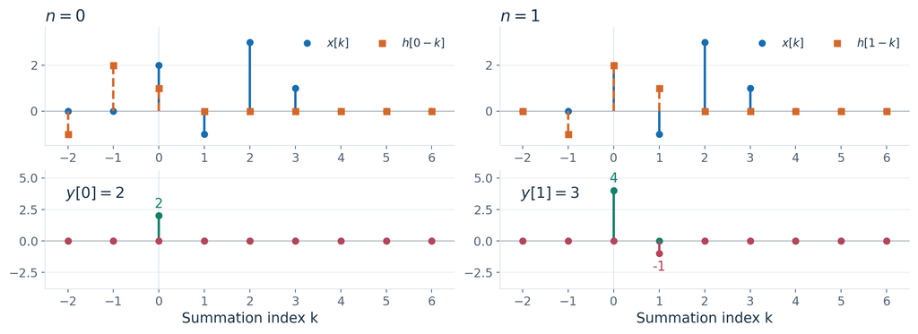

$$y[0]=(2)(1)=2,\qquad y[1]=(2)(2)+(-1)(1)=3.$$

## Discrete example: cancellation at $n=2$

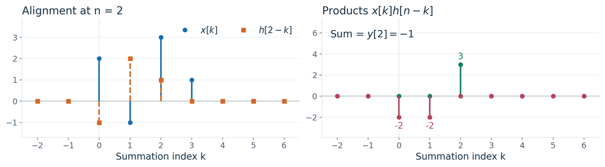

$$y[2]=(2)(-1)+(-1)(2)+(3)(1)=-2-2+3=\boxed{-1}.$$

**The products add with their signs**

Negative contributions can outweigh positive contributions, even with full response overlap.

## Discrete example: reinforcement at $n=3$

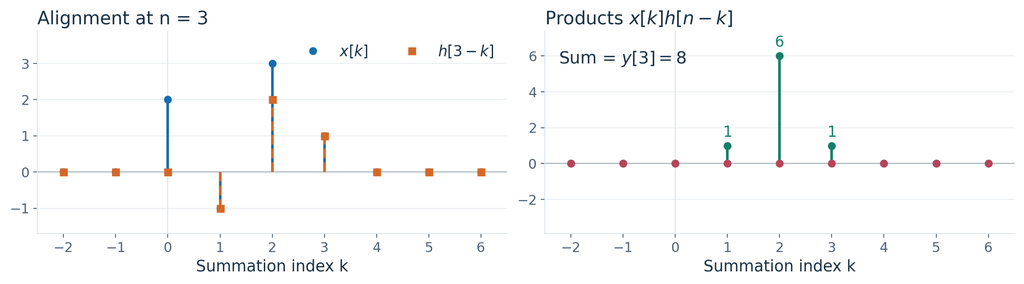

$$y[3]=(-1)(-1)+(3)(2)+(1)(1)=1+6+1=\boxed{8}.$$

The negative input sample and the negative coefficient now produce a positive contribution.

## Discrete example: the last two output samples

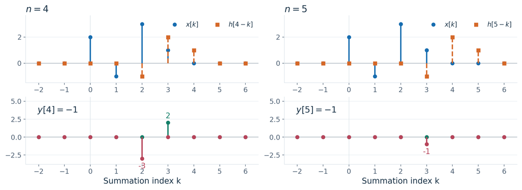

$$y[4]=(3)(-1)+(1)(2)=-1,\qquad y[5]=(1)(-1)=-1.$$

## Discrete example: every product and sum

For each output index, $y[n]=\sum_{k=0}^{3}x[k]h[n-k]$.

| $n$ | $x[0]h[n]$ | $x[1]h[n-1]$ | $x[2]h[n-2]$ | $x[3]h[n-3]$ | $y[n]$ |
| --- | --- | --- | --- | --- | --- |
| $0$ | $2$ | $0$ | $0$ | $0$ | **2** |
| $1$ | $4$ | $-1$ | $0$ | $0$ | **3** |
| $2$ | $-2$ | $-2$ | $3$ | $0$ | **-1** |
| $3$ | $0$ | $1$ | $6$ | $1$ | **8** |
| $4$ | $0$ | $0$ | $-3$ | $2$ | **-1** |
| $5$ | $0$ | $0$ | $0$ | $-1$ | **-1** |

Every row fixes the output index $n$. Each column tracks one input sample.

## Discrete example: the complete output

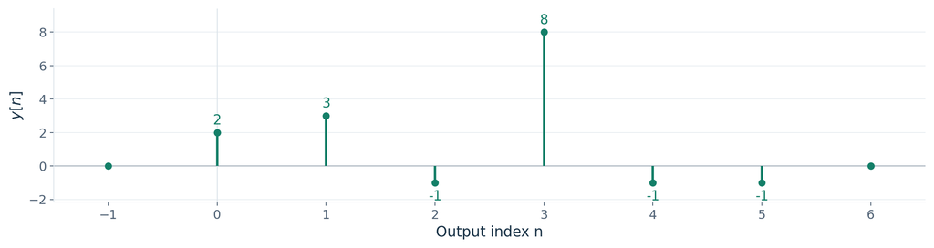

$$\boxed{y[n]=\{2,\ 3,\ -1,\ 8,\ -1,\ -1\},\quad n=0,\ldots,5}$$

Output length: $L_y=L_x+L_h-1=4+3-1=6$ samples.

Sum check: $\sum_n y[n]=10=(\sum_nx[n])(\sum_nh[n])=(5)(2)$.

## Discrete example: Python and filter meaning

```python
import numpy as np

x = np.array([2, -1, 3, 1])       # n = 0, ..., 3
h = np.array([1, 2, -1])         # n = 0, ..., 2
y = np.convolve(x, h, mode="full")
print(y.tolist())
```

```
[2, 3, -1, 8, -1, -1]
```

The same FIR system has the difference equation
$$y[n]=x[n]+2x[n-1]-x[n-2].$$

It combines the current sample with two past samples. Initial rest sets earlier input values to zero.

## Continuous and discrete convolution

| Feature | Continuous example | Discrete example |
| --- | --- | --- |
| Moving response | $h(t-\tau)$ | $h[n-k]$ |
| Variable to eliminate | $\tau$ | $k$ |
| Accumulation | Integral of the product | Signed sum of products |
| Complete output | $0<t<3$ | $n=0,\ldots,5$ |
| Negative output here? | No: both factors are nonnegative | Yes: signed products can cancel |

**One shift produces one output value**

Sweeping all shifts constructs the output signal. Reversing time preserves amplitudes and changes their alignment.

## Questions for discussion

1. At $t=2.5$, why does the continuous integral stop at $\tau=2$?
2. Why does $y[2]$ become negative while $y[3]$ becomes positive?
3. Where does the sample $h[2]=-1$ appear in $h[n-k]$?
4. Why must the continuous output vanish after $t=3$ and the discrete output after $n=5$?

**Expected reasoning**

Identify the overlap limits, preserve signs, and justify each contributing product.

## Reading and course alignment

**Main reference**

John Semmlow (2018). *Circuits, Signals, and Systems for Bioengineers: A MATLAB-Based Introduction*. 3rd edition. Academic Press.

- Section **5.4**, printed pp. **216-225**: convolution and worked examples.
- Eq. **5.2**, p. **218**: continuous convolution.
- Eq. **5.3**, p. **220**: discrete convolution.

**SYSB course topic**

Time-domain analysis of linear systems: convolution. The supplied program schedules definition and application in week 11.

Waveforms, figures, worked calculations, and Python examples in this deck are original teaching material. All signals are synthetic.